# Final_temperature-analysis

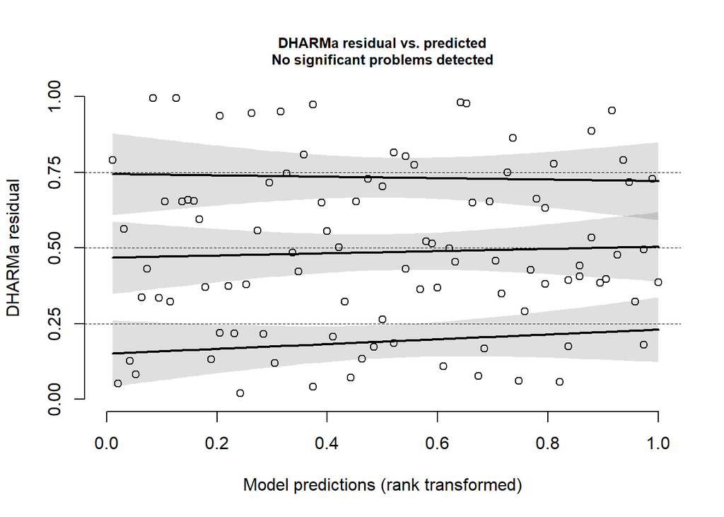

```r
plotResiduals(simulationOutput4)
```

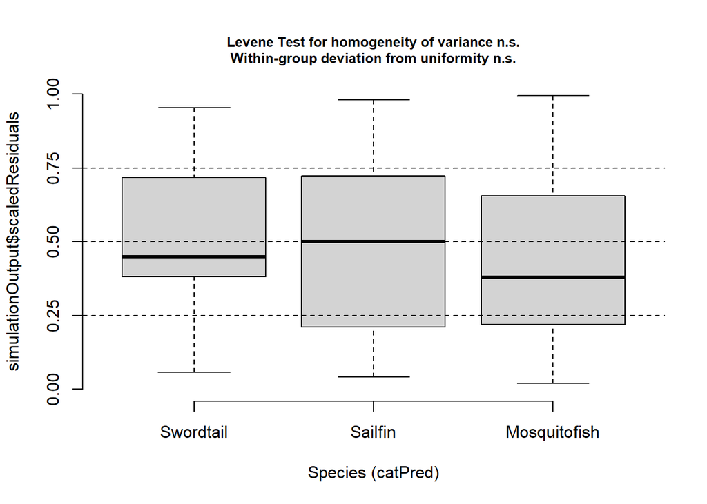

```r
plotResiduals(simulationOutput4, form = rawTempData$Species)
```

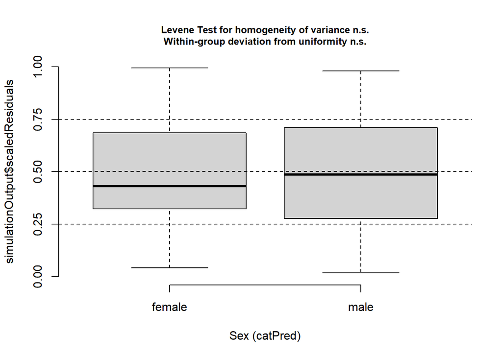

```r
plotResiduals(simulationOutput4, form = rawTempData$Sex)
```

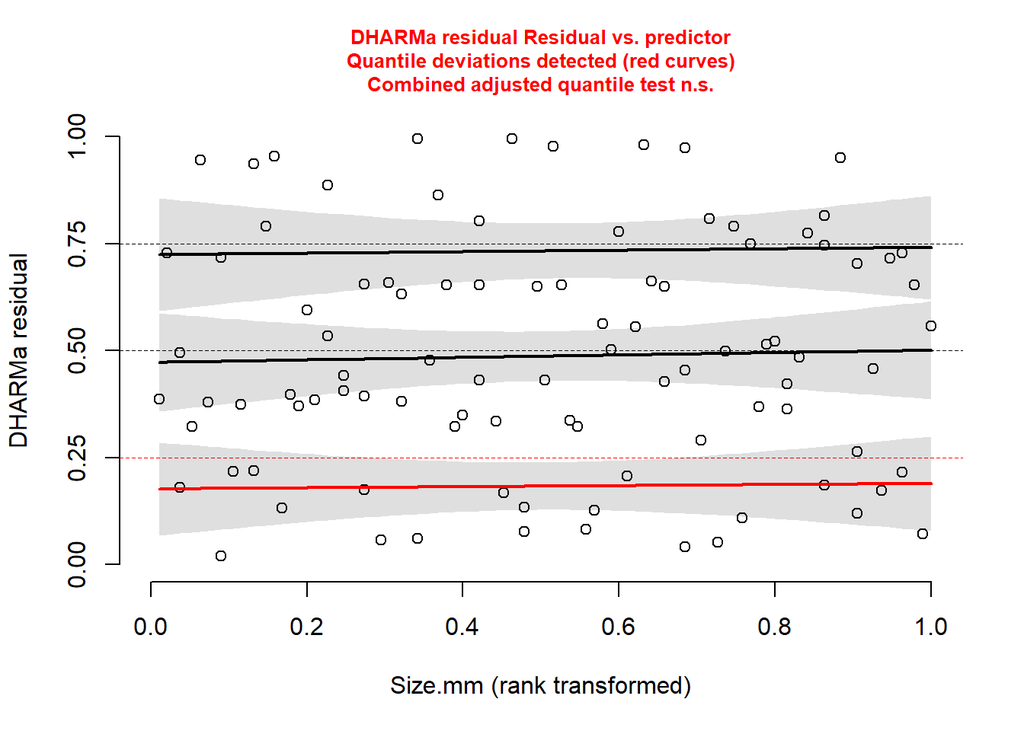

```r
plotResiduals(simulationOutput4, form = rawTempData$Size.mm)
```

```r
  ### Quantitle deviation detected for lower quantile, but combined adjusted quantiles test ns
```

### Model Summary

**Results:** There is a significant effect of species for CTmin (P<0.001). Pairwise comparisons show swordtails as significantly different from sailfin and mosquitofish, and the difference between sailfin and mosquitofish was marginal (0.050). Despite the additions of sex and size improving model fit, neither were statistically significant.

```r
# SPECIES ONLY MODEL
 ## Overall species effect
anova(mod2, type = 2, ddf = "Satterthwaite") #significant (p<0.001)
```

```
## Type II Analysis of Variance Table with Satterthwaite's method
##         Sum Sq Mean Sq NumDF  DenDF F value    Pr(>F)
## Species 11.217  5.6087     2 12.021  16.664 0.0003421 ***
## ---
## Signif. codes:  0 '***' 0.001 '**' 0.01 '*' 0.05 '.' 0.1 ' ' 1
```

```r
 ## EMM & Pairwise comparisons

PW.sp.max <- emmeans(mod2, "Species", lmer.df = "satterthwaite")
summary(PW.sp.max) #EMM
```

```
##  Species      emmean    SE   df lower.CL upper.CL
##  Swordtail      9.84 0.586 12.1     8.56    11.11
##  Sailfin        6.70 0.524 12.0     5.56     7.84
##  Mosquitofish   4.84 0.676 12.0     3.36     6.31
##
## Degrees-of-freedom method: satterthwaite
## Confidence level used: 0.95
```

```r
pairs(PW.sp.max, adjust = "holm") #Pairwise results
```

```
##  contrast                 estimate    SE df t.ratio p.value
##  Swordtail - Sailfin          3.14 0.786 12   3.993  0.0035
##  Swordtail - Mosquitofish     5.00 0.894 12   5.589  0.0004
##  Sailfin - Mosquitofish       1.86 0.855 12   2.177  0.0501
##
## Degrees-of-freedom method: satterthwaite
## P value adjustment: holm method for 3 tests
```

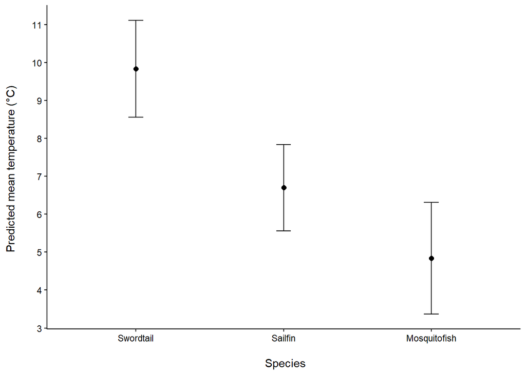

```r
 ## Plotting EMM

PW.df <- as.data.frame(confint(PW.sp.max))

ggplot(PW.df, aes(x=Species, y=emmean)) +
  geom_point(size=2) +
  geom_errorbar(aes(ymin=lower.CL, ymax=upper.CL), width=0.1) +
  scale_y_continuous(breaks = scales::pretty_breaks(n = 10)) +
  ylab("Predicted mean temperature (°C) \n") +
  xlab("\n Species") +
  theme_classic()
```

```r
# SPECIES & SIZE MODEL

summary(mod2b)
```

```
## Linear mixed model fit by maximum likelihood . t-tests use Satterthwaite's
##   method [lmerModLmerTest]
## Formula: CTmin.C ~ Species + Size.mm + (1 | file.id.min)
##    Data: datTot
##
##       AIC       BIC    logLik -2*log(L)  df.resid
##     216.8     232.1    -102.4     204.8        89
##
## Scaled residuals:
##     Min      1Q  Median      3Q     Max
## -1.8543 -0.5770 -0.1414  0.5785  2.3041
##
## Random effects:
##  Groups      Name        Variance Std.Dev.
##  file.id.min (Intercept) 1.3256   1.1513
##  Residual                0.3247   0.5698
## Number of obs: 95, groups:  file.id.min, 12
##
## Fixed effects:
##                     Estimate Std. Error       df t value Pr(>|t|)
## (Intercept)         10.48806    0.69330 23.05393  15.128 1.84e-13 ***
## SpeciesSailfin      -2.91894    0.79449 12.65609  -3.674 0.002926 **
## SpeciesMosquitofish -4.99075    0.89291 12.02234  -5.589 0.000117 ***
## Size.mm             -0.02608    0.01487 84.56561  -1.754 0.083124 .
## ---
## Signif. codes:  0 '***' 0.001 '**' 0.01 '*' 0.05 '.' 0.1 ' ' 1
##
## Correlation of Fixed Effects:
##             (Intr) SpcsSl SpcsMs
## SpeciesSlfn -0.537
## SpcsMsqtfsh -0.550  0.483
## Size.mm     -0.536 -0.157 -0.005
```

```r
anova(mod2b, type = 2, ddf = "Satterthwaite")
```

```
## Type II Analysis of Variance Table with Satterthwaite's method
##          Sum Sq Mean Sq NumDF  DenDF F value    Pr(>F)
## Species 10.5438  5.2719     2 12.400 16.2363 0.0003443 ***
## Size.mm  0.9985  0.9985     1 84.566  3.0751 0.0831244 .
## ---
## Signif. codes:  0 '***' 0.001 '**' 0.01 '*' 0.05 '.' 0.1 ' ' 1
```

```r
# SPECIES & SEX MODEL

summary(mod2c)
```

```
## Linear mixed model fit by maximum likelihood . t-tests use Satterthwaite's
##   method [lmerModLmerTest]
## Formula: CTmin.C ~ Species + Sex + (1 | file.id.min)
##    Data: datTot
##
##       AIC       BIC    logLik -2*log(L)  df.resid
##     216.4     231.7    -102.2     204.4        89
##
## Scaled residuals:
##     Min      1Q  Median      3Q     Max
## -1.8709 -0.6055 -0.1120  0.5085  2.5286
##
## Random effects:
##  Groups      Name        Variance Std.Dev.
##  file.id.min (Intercept) 1.3337   1.1548
##  Residual                0.3229   0.5682
## Number of obs: 95, groups:  file.id.min, 12
##
## Fixed effects:
##                     Estimate Std. Error      df t value Pr(>|t|)
## (Intercept)           9.7270     0.5897 12.3082  16.495  9.2e-10 ***
## SpeciesSailfin       -3.1379     0.7869 12.0430  -3.988 0.001788 **
## SpeciesMosquitofish  -5.0031     0.8955 12.0208  -5.587 0.000118 ***
## Sexmale               0.2179     0.1167 83.0271   1.867 0.065390 .
## ---
## Signif. codes:  0 '***' 0.001 '**' 0.01 '*' 0.05 '.' 0.1 ' ' 1
##
## Correlation of Fixed Effects:
##             (Intr) SpcsSl SpcsMs
## SpeciesSlfn -0.742
## SpcsMsqtfsh -0.652  0.489
## Sexmale     -0.099  0.000 -0.002
```

```r
anova(mod2c, type = 2, ddf = "Satterthwaite")
```

```
## Type II Analysis of Variance Table with Satterthwaite's method
##          Sum Sq Mean Sq NumDF  DenDF F value    Pr(>F)
## Species 10.7502  5.3751     2 12.020 16.6466 0.0003438 ***
## Sex      1.1259  1.1259     1 83.027  3.4868 0.0653899 .
## ---
## Signif. codes:  0 '***' 0.001 '**' 0.01 '*' 0.05 '.' 0.1 ' ' 1
```

```r
# SPECIES, SIZE & SEX MODEL

summary(mod2d)
```

```
## Linear mixed model fit by maximum likelihood . t-tests use Satterthwaite's
##   method [lmerModLmerTest]
## Formula: CTmin.C ~ Species + Sex + Size.mm + (1 | file.id.min)
##    Data: datTot
##
##       AIC       BIC    logLik -2*log(L)  df.resid
##     215.9     233.7    -100.9     201.9        88
##
## Scaled residuals:
##     Min      1Q  Median      3Q     Max
## -2.0432 -0.4993 -0.1072  0.5366  2.5183
##
## Random effects:
##  Groups      Name        Variance Std.Dev.
##  file.id.min (Intercept) 1.3301   1.1533
##  Residual                0.3134   0.5598
## Number of obs: 95, groups:  file.id.min, 12
##
## Fixed effects:
##                     Estimate Std. Error       df t value Pr(>|t|)
## (Intercept)         10.32329    0.69701 23.41546  14.811 2.19e-13 ***
## SpeciesSailfin      -2.94085    0.79512 12.63812  -3.699 0.002800 **
## SpeciesMosquitofish -4.99518    0.89392 12.02156  -5.588 0.000118 ***
## Sexmale              0.19881    0.11556 83.04387   1.720 0.089089 .
## Size.mm             -0.02347    0.01469 84.52590  -1.597 0.113961
## ---
## Signif. codes:  0 '***' 0.001 '**' 0.01 '*' 0.05 '.' 0.1 ' ' 1
##
## Correlation of Fixed Effects:
##             (Intr) SpcsSl SpcsMs Sexmal
## SpeciesSlfn -0.536
## SpcsMsqtfsh -0.548  0.484
## Sexmale     -0.137 -0.016 -0.003
## Size.mm     -0.536 -0.155 -0.005  0.103
```

```r
anova(mod2d, type = 2, ddf = "Satterthwaite")
```

```
## Type II Analysis of Variance Table with Satterthwaite's method
##          Sum Sq Mean Sq NumDF  DenDF F value    Pr(>F)
## Species 10.1925  5.0963     2 12.389 16.2602 0.0003431 ***
## Sex      0.9276  0.9276     1 83.044  2.9597 0.0890885 .
## Size.mm  0.7995  0.7995     1 84.526  2.5509 0.1139615
## ---
## Signif. codes:  0 '***' 0.001 '**' 0.01 '*' 0.05 '.' 0.1 ' ' 1
```

```r
# SUMMARY TABLE

ctmin.results <- bind_rows(
  coef.table(mod2b, "B", "Size.mm"),
  coef.table(mod2c, "C", "^Sex"),
  coef.table(mod2d, "D", "Size.mm|^Sex"))

ctmin.results
```

```
##   Predictor    Estimate Std. Error       df   t value   Pr(>|t|) Model
## 1   Size.mm -0.02607947 0.01487206 84.56561 -1.753588 0.08312441     B
## 2   Sexmale  0.21785113 0.11666691 83.02706  1.867291 0.06538985     C
## 3   Sexmale  0.19880805 0.11556080 83.04387  1.720376 0.08908850     D
## 4   Size.mm -0.02346656 0.01469266 84.52590 -1.597163 0.11396146     D
##        CI_low     CI_high
## 1 -0.05565130 0.003492364
## 2 -0.01419355 0.449895808
## 3 -0.03103594 0.428652041
## 4 -0.05268187 0.005748742
```

## **Across male morphs**

### Models

For both CTmax and CTmin, a model of temperature ~ sex category was the most supported, although adding size was also competative for CTmax.

```r
#swordtail only data frame; will use dat.plot df as it has male morphs already
swordtail.df <- dat.plot %>%
  filter(Species == "Swordtail")


### CTmax ###
SWmod1 <- lmer(CTmax.C ~ Sex.plot + (1|file.id.max), data = swordtail.df, REML = FALSE)
```

```
## boundary (singular) fit: see help('isSingular')
```

```r
SWmod2 <- lmer(CTmax.C ~ Sex.plot + Size.mm + (1|file.id.max), data = swordtail.df, REML = FALSE)
```

```
## boundary (singular) fit: see help('isSingular')
```

```r
SWmod3 <- lmer(CTmax.C ~ Sex.plot * Size.mm + (1|file.id.max), data = swordtail.df, REML = FALSE)
```

```
## boundary (singular) fit: see help('isSingular')
```

```r
model.sel(SWmod1, SWmod2, SWmod3)
```

```
## Model selection table
##        (Int) Sex.plt  Siz.mm Sex.plt:Siz.mm df  logLik  AICc delta weight
## SWmod1 35.17       +                         5 -42.118  96.7  0.00   0.71
## SWmod2 37.66       + -0.1079                 6 -41.472  98.6  1.86   0.28
## SWmod3 39.45       + -0.1852              +  8 -41.166 105.2  8.45   0.01
## Models ranked by AICc(x)
## Random terms (all models):
##   1 | file.id.max
```

```r
    ### SWmod1 with best support (ΔAICc=0; weight=0.71) although adding size (SWmod2) is also competative (ΔAICc=1.86; weight=0.28).

### CTmin ###
SWmod4 <- lmer(CTmin.C ~ Sex.plot + (1|file.id.min), data = swordtail.df, REML = FALSE)
SWmod5 <- lmer(CTmin.C ~ Sex.plot + Size.mm + (1|file.id.min), data = swordtail.df, REML = FALSE)
SWmod6 <- lmer(CTmin.C ~ Sex.plot * Size.mm + (1|file.id.min), data = swordtail.df, REML = FALSE)

model.sel(SWmod4, SWmod5, SWmod6)
```

```
## Model selection table
##         (Int) Sex.plt   Siz.mm Sex.plt:Siz.mm df  logLik AICc delta weight
## SWmod4  9.716       +                          5 -22.795 58.1  0.00  0.748
## SWmod5 10.690       + -0.04217                 6 -22.348 60.3  2.26  0.242
## SWmod6 12.040       + -0.10050              +  8 -22.004 66.9  8.77  0.009
## Models ranked by AICc(x)
## Random terms (all models):
##   1 | file.id.min
```

```r
    ### SWmod4 with best support (ΔAICc=0; weight=0.748); adding size or an interaction did not improve fit nor are competative models (ΔAICc >2).
```

### Residual checks

Here, we will check if the model residuals are normal and homoscedastic using the ‘DHARMa’ package.

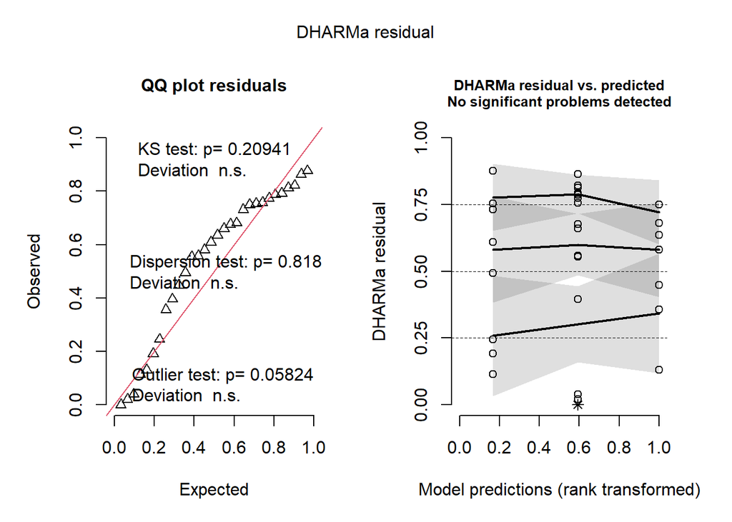

```r
# CTmax
simulationOutput <- simulateResiduals(SWmod1, n = 1000)

plot(simulationOutput)
```

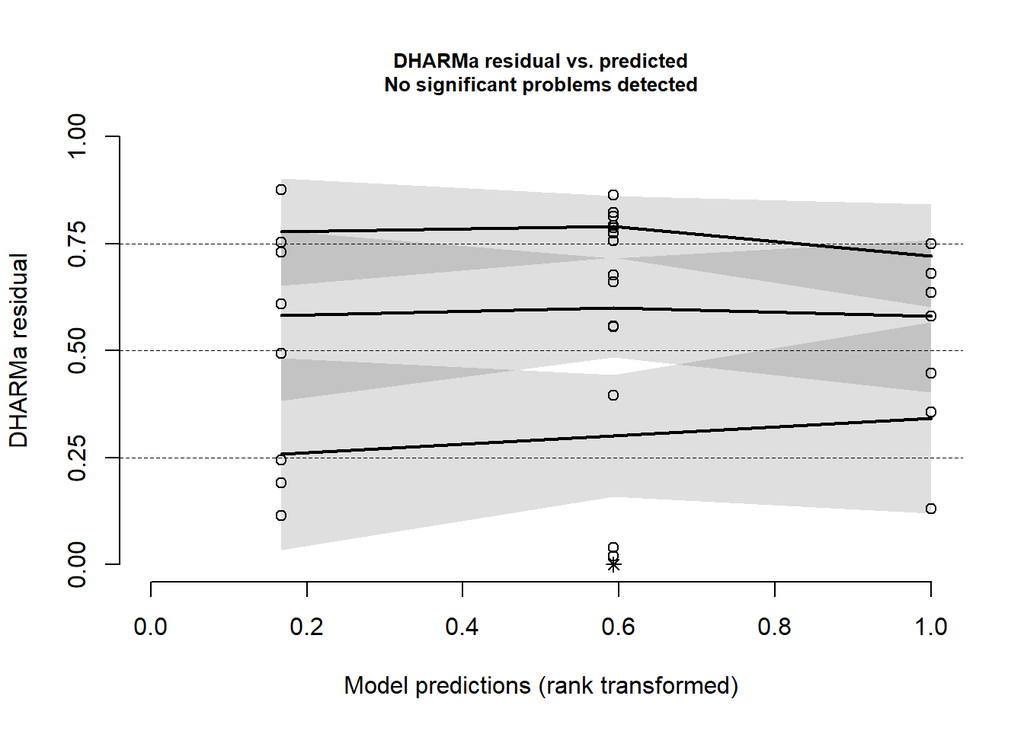

```r
plotResiduals(simulationOutput)
```

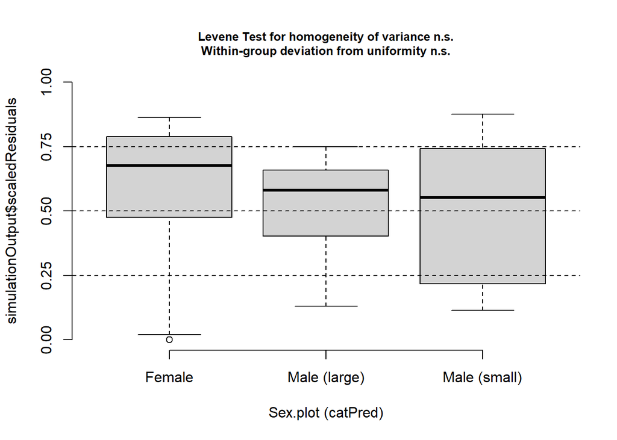

```r
plotResiduals(simulationOutput, form = swordtail.df$Sex.plot)
```

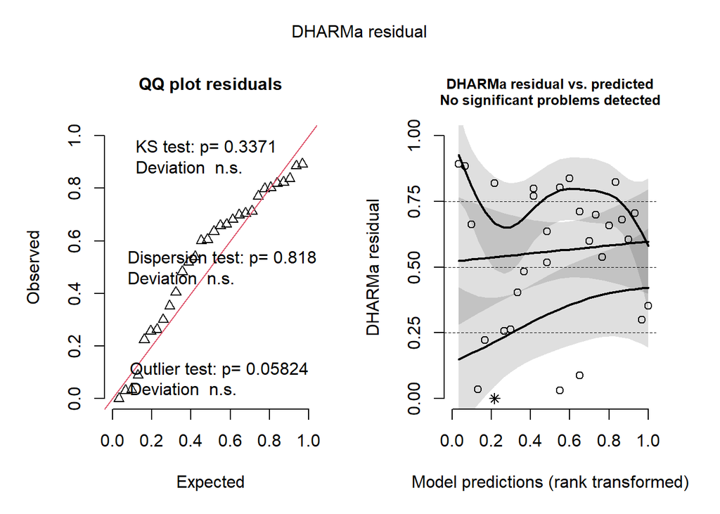

```r
  ### All good!


simulationOutput <- simulateResiduals(SWmod2, n = 1000)

plot(simulationOutput)
```

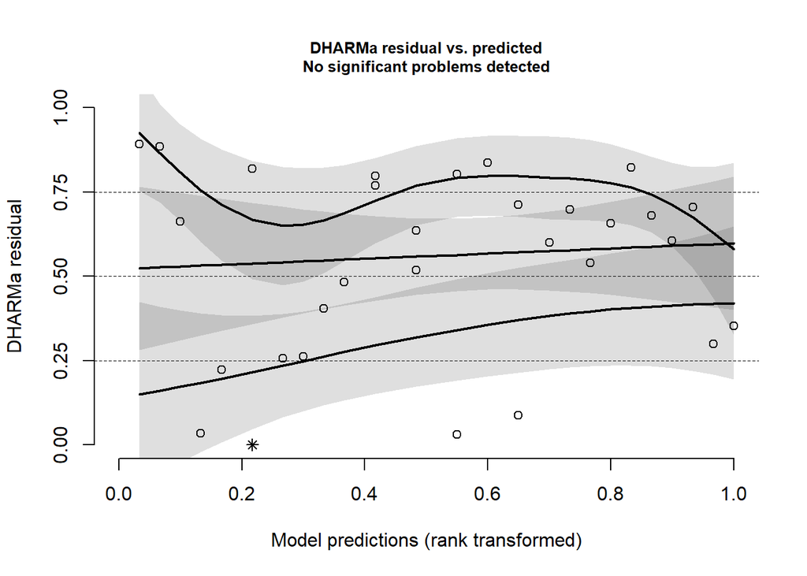

```r
plotResiduals(simulationOutput)
```

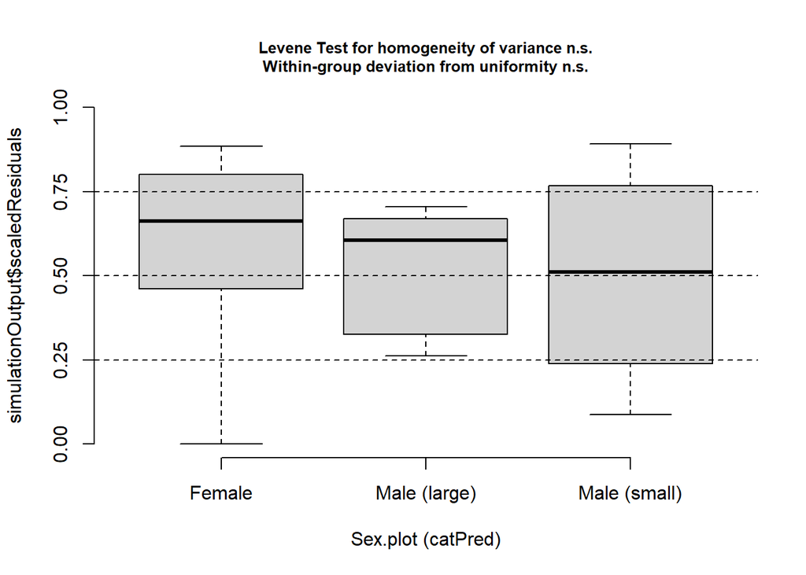

```r
plotResiduals(simulationOutput, form = swordtail.df$Sex.plot)
```

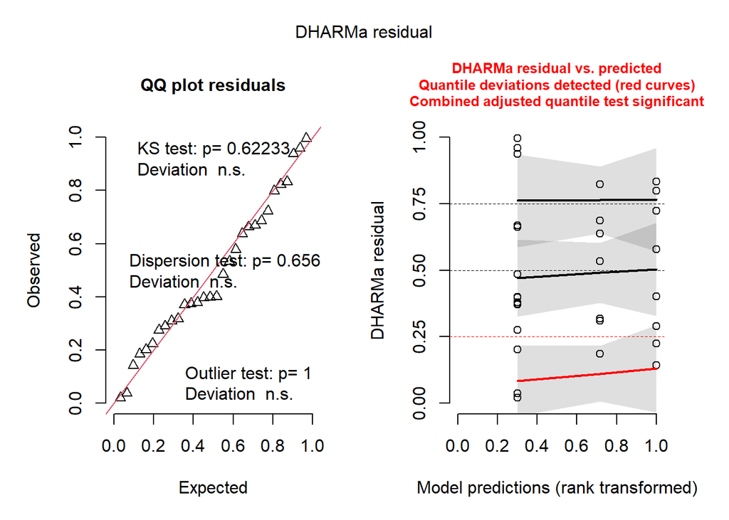

```r
  ### All good!

# CTmin
simulationOutput <- simulateResiduals(SWmod4, n = 1000)

plot(simulationOutput)
```

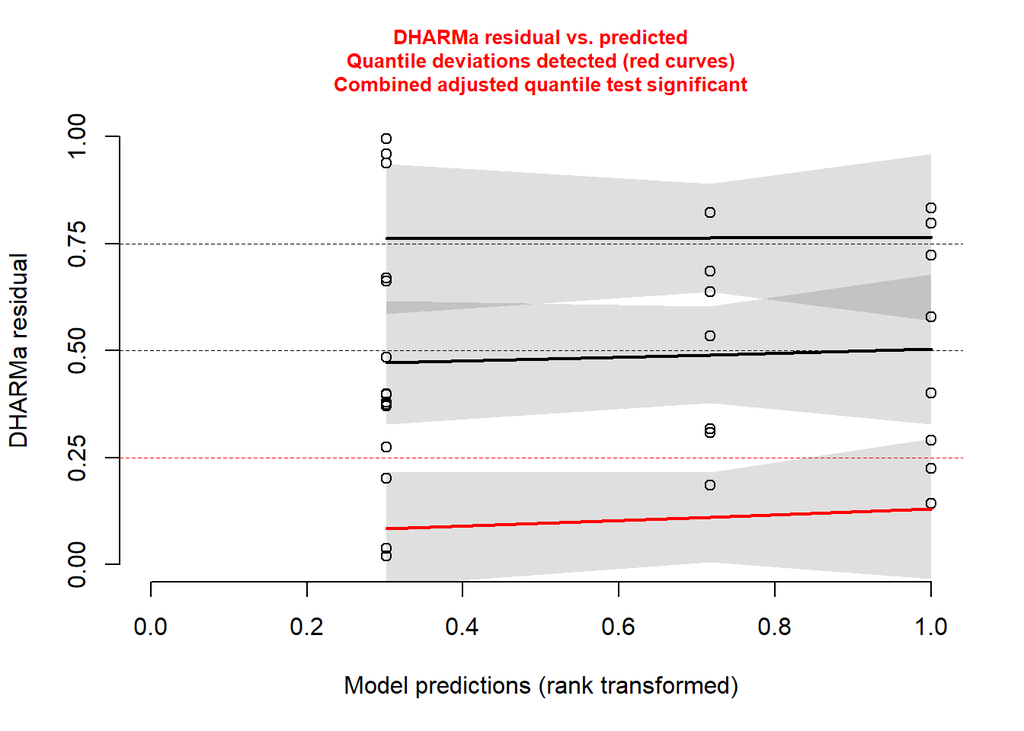

```r
plotResiduals(simulationOutput)
```

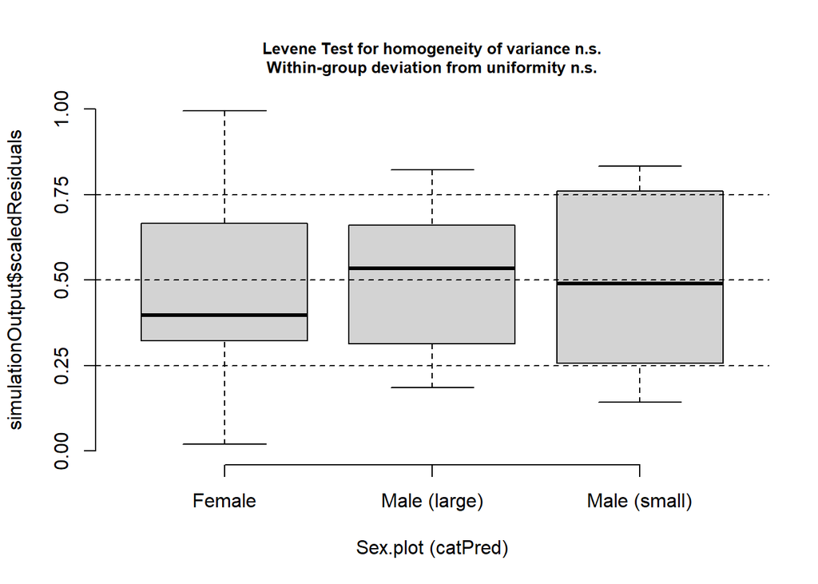

```r
plotResiduals(simulationOutput, form = swordtail.df$Sex.plot) #threw a quantile deviation, but not sure if this is real or side effect of small samples
```

```r
cat_test <- plotResiduals(simulationOutput, form = swordtail.df$Sex.plot)
cat_test$uniformity$p.value.cor # all = 1
```

[output not shown]

```r
cat_test$homogeneity #p = 0.836
```

[output not shown]

```r
  ### All good!
```

### Model Summary

**Results:** Sex category (large male, small male, female) did not significantly affect thermal tolerance within swordtails across both temperature categories (CTmax: p=0.617; CTmin: p=0.275). This result is mirrored in all pairwise comparisons.

```r
# SEX CATEGORY ONLY MODEL
 ## Overall sex category effect
anova(SWmod1, type = 2, ddf = "Satterthwaite") #not significant (p=0.617)
```

```
## Type II Analysis of Variance Table with Satterthwaite's method
##           Sum Sq Mean Sq NumDF DenDF F value Pr(>F)
## Sex.plot 0.95339 0.47669     2    30  0.4912 0.6167
```

```r
 ## EMM & Pairwise comparisons

PW.sw.max <- emmeans(SWmod1, "Sex.plot", lmer.df = "satterthwaite")
summary(PW.sw.max) #EMM
```

```
##  Sex.plot     emmean    SE df lower.CL upper.CL
##  Female         35.2 0.254 30     34.7     35.7
##  Male (large)   35.6 0.372 30     34.8     36.4
##  Male (small)   35.2 0.348 30     34.5     35.9
##
## Degrees-of-freedom method: satterthwaite
## Confidence level used: 0.95
```

```r
pairs(PW.sw.max, adjust = "holm") #Pairwise results
```

```
##  contrast                    estimate    SE df t.ratio p.value
##  Female - Male (large)        -0.4187 0.451 30  -0.928  1.0000
##  Female - Male (small)         0.0079 0.431 30   0.018  1.0000
##  Male (large) - Male (small)   0.4266 0.510 30   0.837  1.0000
##
## Degrees-of-freedom method: satterthwaite
## P value adjustment: holm method for 3 tests
```

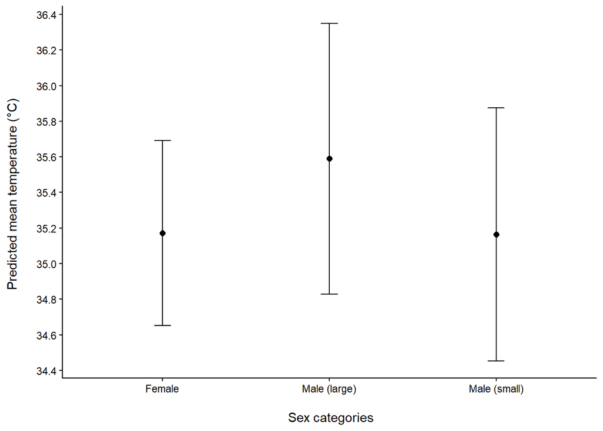

```r
 ## Plotting EMM

PW.df.sw <- as.data.frame(confint(PW.sw.max))

ggplot(PW.df.sw, aes(x=Sex.plot, y=emmean)) +
  geom_point(size=2) +
  geom_errorbar(aes(ymin=lower.CL, ymax=upper.CL), width=0.1) +
  scale_y_continuous(breaks = scales::pretty_breaks(n = 10)) +
  ylab("Predicted mean temperature (°C) \n") +
  xlab("\n Sex categories") +
  theme_classic()
```

```r
# SEX CATEGORY & SIZE MODEL

summary(SWmod2)
```

```
## Linear mixed model fit by maximum likelihood . t-tests use Satterthwaite's
##   method [lmerModLmerTest]
## Formula: CTmax.C ~ Sex.plot + Size.mm + (1 | file.id.max)
##    Data: swordtail.df
##
##       AIC       BIC    logLik -2*log(L)  df.resid
##      94.9     103.4     -41.5      82.9        24
##
## Scaled residuals:
##     Min      1Q  Median      3Q     Max
## -3.0658 -0.5445  0.3018  0.7201  1.2398
##
## Random effects:
##  Groups      Name        Variance Std.Dev.
##  file.id.max (Intercept) 0.0000   0.0000
##  Residual                0.9295   0.9641
## Number of obs: 30, groups:  file.id.max, 4
##
## Fixed effects:
##                      Estimate Std. Error       df t value Pr(>|t|)
## (Intercept)          37.66372    2.18317 30.00000  17.252   <2e-16 ***
## Sex.plotMale (large)  1.60445    1.12231 30.00000   1.430    0.163
## Sex.plotMale (small) -0.36322    0.52323 30.00000  -0.694    0.493
## Size.mm              -0.10786    0.09387 30.00000  -1.149    0.260
## ---
## Signif. codes:  0 '***' 0.001 '**' 0.01 '*' 0.05 '.' 0.1 ' ' 1
##
## Correlation of Fixed Effects:
##             (Intr) Sx.pltM(l) Sx.pltM(s)
## Sx.pltM(lr)  0.888
## Sx.pltM(sm) -0.641 -0.438
## Size.mm     -0.993 -0.919      0.591
## optimizer (nloptwrap) convergence code: 0 (OK)
## boundary (singular) fit: see help('isSingular')
```

```r
# CTmin

# SEX CATEGORY ONLY MODEL
 ## Overall sex category effect
anova(SWmod4, type = 2, ddf = "Satterthwaite") #not significant (p=0.275)
```

```
## Type II Analysis of Variance Table with Satterthwaite's method
##           Sum Sq Mean Sq NumDF  DenDF F value Pr(>F)
## Sex.plot 0.54844 0.27422     2 27.793  1.3526 0.2751
```

```r
 ## EMM & Pairwise comparisons

PW.sw.min <- emmeans(SWmod4, "Sex.plot", lmer.df = "satterthwaite")
summary(PW.sw.min) #EMM
```

```
##  Sex.plot     emmean    SE   df lower.CL upper.CL
##  Female         9.72 0.248 5.04     9.08     10.4
##  Male (large)   9.86 0.296 8.94     9.19     10.5
##  Male (small)  10.06 0.289 8.27     9.39     10.7
##
## Degrees-of-freedom method: satterthwaite
## Confidence level used: 0.95
```

```r
pairs(PW.sw.min, adjust = "holm") #Pairwise results
```

```
##  contrast                    estimate    SE   df t.ratio p.value
##  Female - Male (large)         -0.147 0.233 28.5  -0.631  1.0000
##  Female - Male (small)         -0.341 0.219 28.2  -1.553  0.3945
##  Male (large) - Male (small)   -0.193 0.311 29.9  -0.622  1.0000
##
## Degrees-of-freedom method: satterthwaite
## P value adjustment: holm method for 3 tests
```

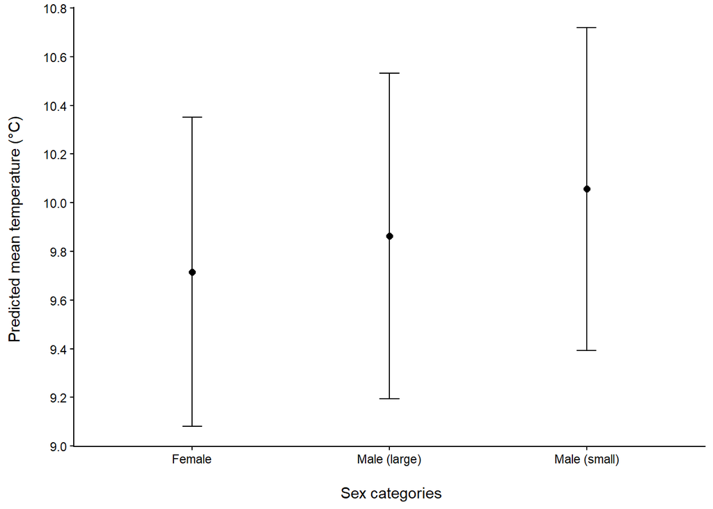

```r
 ## Plotting EMM

PW.df.sw2 <- as.data.frame(confint(PW.sw.min))

ggplot(PW.df.sw2, aes(x=Sex.plot, y=emmean)) +
  geom_point(size=2) +
  geom_errorbar(aes(ymin=lower.CL, ymax=upper.CL), width=0.1) +
  scale_y_continuous(breaks = scales::pretty_breaks(n = 10)) +
  ylab("Predicted mean temperature (°C) \n") +
  xlab("\n Sex categories") +
  theme_classic()
```

# **Power Analysis**

Based on the power of our current study, we will calculate the average temperature difference needed to detect a significant sex effect.

**Results:** The actual temperature difference between males and females in each category was much lower than the simulated temperature differences needed to detect a sex effect given the power of our study (Actual: CTmax=0.2, CTmin=0.1; Simulated: CTmax=0.6, CTmin=0.3). While we found no statistically significant sex effect in any temperature category, smaller biologically meaningful differences can not be ruled out due to our limited sample size.

*NOTE:* This will increase loading time; to reduce loading time, remove/comment out the following section and keep the comparisons table to view results.

Power simulation:

```r
# Function to simulate power and find minimum detectable sex difference
# Inputs:
#   nsim: number of simulations per effect size
#   species: vector of species names
#   nM, nF: vectors of males/females per species
#   sigma: residual SD from linear model
#   alpha: significance threshold
#   power_target: desired power (e.g., 0.8)
#   delta_range: vector of sex differences to test
#   trait_name: name of the trait (for labeling)

simulate_MDD <- function(nsim=1000, species, nM, nF, sigma, alpha=0.05,
                         power_target=0.8, delta_range=seq(0, 3, by=0.1),
                         trait_name="Trait") {

  power_results <- data.frame(delta = delta_range, power = NA)

  for(i in seq_along(delta_range)){
    sig_count <- 0
    for(j in 1:nsim){
      temp <- c()
      sex <- c()
      sp <- c()

      for(k in seq_along(species)){
        # simulate male and female data around delta/2 difference
        temp <- c(temp,
                  rnorm(nM[k], mean = delta_range[i]/2, sd = sigma),
                  rnorm(nF[k], mean = -delta_range[i]/2, sd = sigma))
        sex <- c(sex, rep(c("M","F"), times=c(nM[k], nF[k])))
        sp <- c(sp, rep(species[k], times=nM[k]+nF[k]))
      }

      df <- data.frame(temp=temp, sex=sex, species=sp)

      # Fit linear model
      m <- lm(temp ~ sex + species, data=df)

      # extract p-value for sex
      pval <- summary(m)$coefficients["sexM","Pr(>|t|)"]
      if(!is.na(pval) & pval < alpha) sig_count <- sig_count + 1
    }

    power_results$power[i] <- sig_count / nsim
  }

  # Find minimum detectable delta (closest to target power)
  closest <- power_results$delta[which.min(abs(power_results$power - power_target))]

  cat("\n---", trait_name, "---\n")
  cat("Minimum detectable sex difference for", power_target*100, "% power: ", closest, "\n\n")

  return(list(power_curve = power_results, MDD = closest))
} ### END FUNCTION

# ==========================

species <- c("sailfin","mosquitofish","swordtail")
nM <- c(20, 13, 15) #number of males for each species
nF <- c(20, 12, 15) #number of females for each species

# Sigma values are the residual SD from the above linear models
sigma_CTmax <- 0.9861918   # summary(mod1f)$sigma
sigma_CTmin <- 0.5801441   # summary(mod2f)$sigma

# Run simulations
MDD_CTmax <- simulate_MDD(species=species, nM=nM, nF=nF, sigma=sigma_CTmax, trait_name="CTmax") #0.6°C
```

```
##
## --- CTmax ---
## Minimum detectable sex difference for 80 % power:  0.6
```

```r
MDD_CTmin <- simulate_MDD(species=species, nM=nM, nF=nF, sigma=sigma_CTmin, trait_name="CTmin") #0.3°C
```

```
##
## --- CTmin ---
## Minimum detectable sex difference for 80 % power:  0.3
```

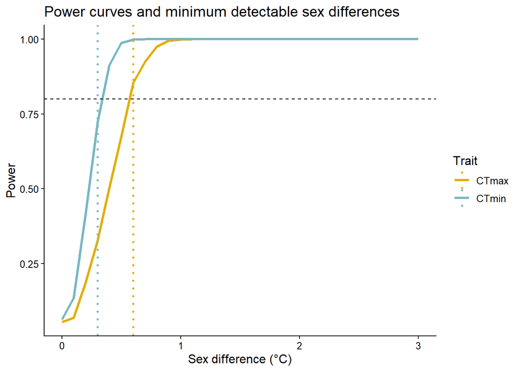

```r
CTmax_df <- MDD_CTmax$power_curve %>% mutate(Trait="CTmax", MDD=MDD_CTmax$MDD)
CTmin_df <- MDD_CTmin$power_curve %>% mutate(Trait="CTmin", MDD=MDD_CTmin$MDD)
power_all <- bind_rows(CTmax_df, CTmin_df)

# Plot
ggplot(power_all, aes(x=delta, y=power, color=Trait)) +
  geom_line(size=1.1) +
  geom_hline(yintercept=0.8, linetype="dashed", color="black") +
  geom_vline(aes(xintercept=MDD, color=Trait), linetype="dotted", size= 1) +
  labs(title="Power curves and minimum detectable sex differences",
       x="Sex difference (°C)",
       y="Power",
       color="Trait") +
  theme_classic() +
  theme(text = element_text(size=12)) +
  scale_color_manual(name="Trait",
                    values = c("CTmax"="#E1AF00", "CTmin"="#78B7C5"),
                    labels = c("CTmax"="CTmax", "CTmin"="CTmin"))
```

Comparisons:

```r
#sex only dfs
males <- rawTempData[rawTempData$Sex == "male",]
females <- rawTempData[rawTempData$Sex == "female",]

#find average differences in real data
(mean(males$CTmax.C))- (mean(females$CTmax.C)) #0.160°C
```

```
## [1] 0.1597895
```

```r
(mean(males$CTmin.C))- (mean(females$CTmin.C)) #0.135°C
```

```
## [1] 0.1345445
```

```r
#final table
df <- data.frame(
  type = c("CTmax", "CTmin"),
  Actual   = c(0.2, 0.1),
  Simulated   = c(0.6, 0.3))
df
```

```
##    type Actual Simulated
## 1 CTmax    0.2       0.6
## 2 CTmin    0.1       0.3
```

# **Summary**

We were interested in whether the sexual dimorphism found in many livebearing species played a role in thermal tolerance. We tested for sex-biased tolerance in CTmax and CTmin trials in three livebearing species: sailfin mollies (*P. latipinna*), Western mosquitofish (*G. affinis*), and Panuco swordtail (*X. nigrensis*). We also tested whether male morphs (i.e. large and small males) within one species (swordtail) affected thermal tolerance.

In both trials (CTmax, CTmin), sex and size did *not* influence thermal tolerance. Instead, only species differences affected thermal tolerance. In general, mosquitofish tolerated the most extreme temperatures, followed by sailfin. Swordtails had the narrowest and weakest thermal tolerance, owing likely to the consistency of temperature at their place of origin (e.g spring-fed rivers).

Likewise, male morphs did *not* influence thermal tolerance, further confirming that this is likely no detectable sex-biased thermal differences in our current setup.

A power analysis shows that the actual detected sex differences in both categories is much lower than the simulated temperature differences needed in order to detect a sex-based effect given the power of our study. Therefore, smaller biologically meaningful differences can not be ruled out due to our limited sample size.